# Case Study: Is Russel Westbrook a good player in the 2021-22 Season?

By Teo Zeng

## Introduction: NBA

Started in the year of 1946, there had been a lot of great players, here are some NBA players that the author like the most:

### Lebron James

[figure not shown]

Lebron James

As of 2022, 37-year-old Lakers player Lebron James has won:

- 4x NBA champion (2012, 2013, 2016, 2020)
- 4x NBA Finals MVP (2012, 2013, 2016, 2020)
- 4x NBA Most Valuable Player (2009, 2010, 2012, 2013)
- 18x NBA All-Star (2005-2022)
- 3x NBA All-Star Game MVP (2006, 2008, 2018)
- 13x All-NBA First Team (2006, 2008-2018, 2020)

### Russel Westbrook

[figure not shown]

Russel Westbrook

As of 2022, 33-year-old Lakers point guard Russel Westbrook has won:

- NBA MVP (2017)
- 9x NBA All-Star (2011-2013, 2015-2020)
- 2x All-NBA First Team (2016, 2017)

## Motivation

On August 6, 2021, Westbrook was traded to the Los Angeles Lakers. As his first season with the Lakers progressed, Westbrook received criticism for his perceived poor quality of play. Westbrook shot 30 percent from the three-point line and turned the ball over 4.6 times per game through early January, and he received criticism for a particular game against the Minnesota Timberwolves where he turned the ball over nine times. Westbrook later responded to critics, saying that they were only looking at the stat sheet and not his overall play on the court.

However, Westbrook also had some remarkable games during the season. On January 4, 2022, in a 122-114 win over the Sacramento Kings, Westbrook had his first game without turnovers since March 14, 2016. On January 29, in a 114-117 loss to the Charlotte Hornets, he scored 35 points, of which 30 in the second half (16 points in the fourth quarter from a 20-point deficit) were the most by any Laker since Kobe Bryant’s last game on April 13, 2016.

Different people had different opinions on Westbrook’s performance. Many Laker’s fan want to trade Westbrook badly, while others feel that Westbrook is still good for the Lakers.

**So the key question arises: Is Westbrook a good player in the 2021-22 season?**

To answer this question we shall introduce another statistics: **2k ratings**. Each year, 2k, a gaming company, releases a version of NBA video game that consist of all the players in the NBA. And base on the performance of each player, 2k assigns a **rating** to each player. The rating is an integer between 0 and 100. The higher a player’s rating, the better a player is. For example, the rating of Lebron James in 2016-17 Season is 99, and the rating of Russell Westbrook in the same season is 93. A typical starter player will have a rating of ~80+, and a typical bench player will have a rating of ~70+.

For this case study, we **assume the fact that each player’s 2k rating is unbiased.** So to answer our case study question, we will use our model to predict the rating of Westbrook, base on his performance at the current season. If the rating is satisfactory, we can conclude that Westbrook is still a good player this season. If not, then we can conclude that Westbrook is not a good player this season.

### An Overview of Dataset

The dataset is downloaded as a csv file and is obtained from a [kaggle dataset by William Yu](https://www.kaggle.com/datasets/willyiamyu/nba-2k-ratings-with-real-nba-stats).

While a full copy of the codebook is available in my zipped files, here are some of the key variables that are helpful to be aware of for this report:

- `PLAYER`: The name of the player
- `TEAM`: The name of the team
- `ratings`: The 2k rating of the player
- `GP`: The number of games played
- `MIN`: The number of minutes played
- `PTS`: The number of points scored
- `AST`: The number of assists
- `REB`: The number of rebounds
- `STL`: The number of steals
- `BLK`: The number of blocks
- `TOV`: The number of turnovers
- `PF`: The number of personal fouls
- `FG%`: The percentage of field goals made
- `3P%`: The percentage of three pointers made
- `FT%`: The percentage of free throws made

### Loading Data and Packages

In this section, We will install some packages for data analysis.

```r
library(ggplot2)
library(tidymodels)
library(corrplot)
library(ggthemes)
library(yardstick)
library(tidyverse)
library(lubridate)
library(tidymodels)
library(corrr)
tidymodels_prefer()

setwd("~/Desktop/PSTAT 131/pstat131-project")
set.seed(1205)
```

Then, we read the dataset.

```r
ratings <- read.csv(file = 'data/nba_rankings_2014-2020.csv')
```

```r
dim(ratings)
```

```
## [1] 2412   32
```

So we see that there are 2412 observations and 32 columns in total.

## Exploratory Data Analysis

### Teams

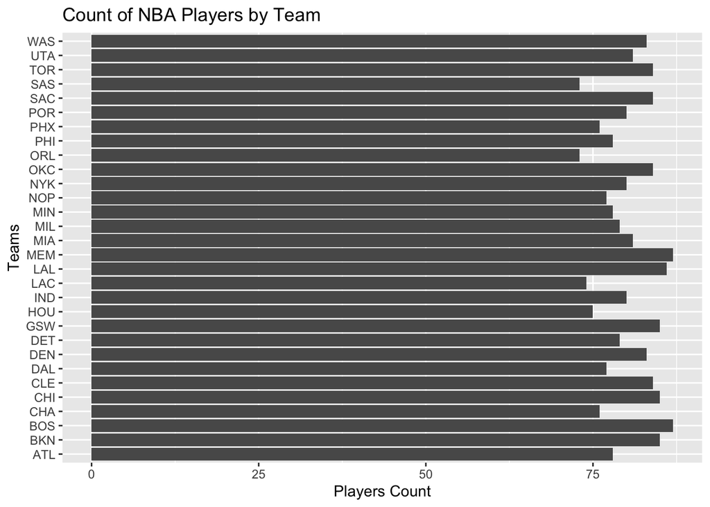

```r
ggplot(ratings, aes(TEAM)) +
  geom_bar() +
  labs(
    title = "Count of NBA Players by Team",
    x = "Teams",
    y = "Players Count"
  ) +
  # We want to be able to read labels better
  coord_flip()
```

So we see that over these years each team has about the same number of players. This makes sense because each NBA team has a minimum player number requirement each year.

### Ratings

Let’s examine `ratings` closely.

#### Histogram of Player Rating by Season

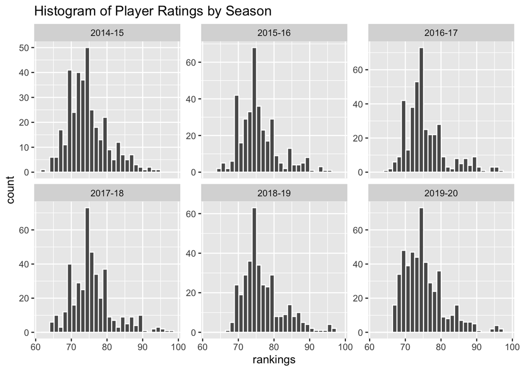

```r
ggplot(ratings, aes(rankings)) +
  geom_histogram(bins = 30, color = "white") +
  facet_wrap(~SEASON, scales = "free_y") +
  labs(
    title = "Histogram of Player Ratings by Season"
  )
```

#### Ratings in each team by Season

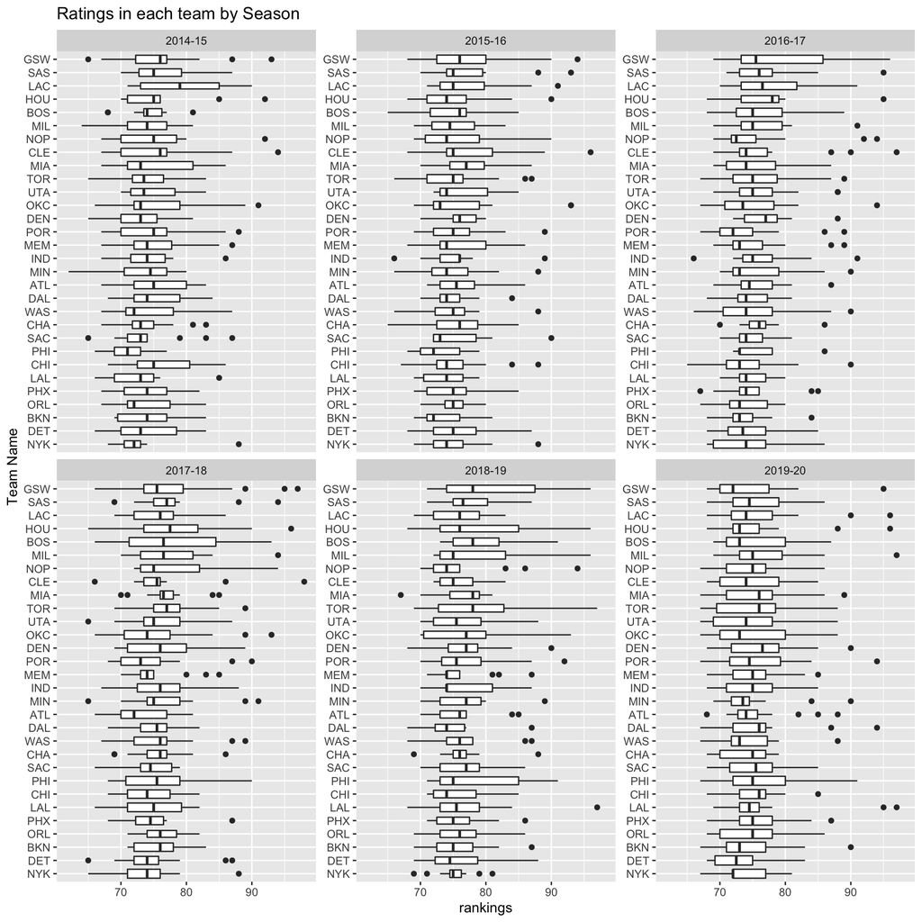

```r
ggplot(ratings, aes(reorder(TEAM, rankings), rankings)) +
  geom_boxplot(varwidth = TRUE) +
    facet_wrap(~SEASON, scales = "free_y") +
  coord_flip() +
  labs(
    title = "Ratings in each team by Season",
    x = "Team Name"
  )
```

The above plot shows how the ratings of players in a team is distributed. And we can make sense of it case by case.

#### Rankings vs. PTS by Season

Looking at the player ratings vs. the average game point of that player across all season, we spot that there is some good linear relationshp between these two variables. So one can conclude that the higher points a player can score in a game, the higher ratings a get, and hence a better player he is. This makes sense.

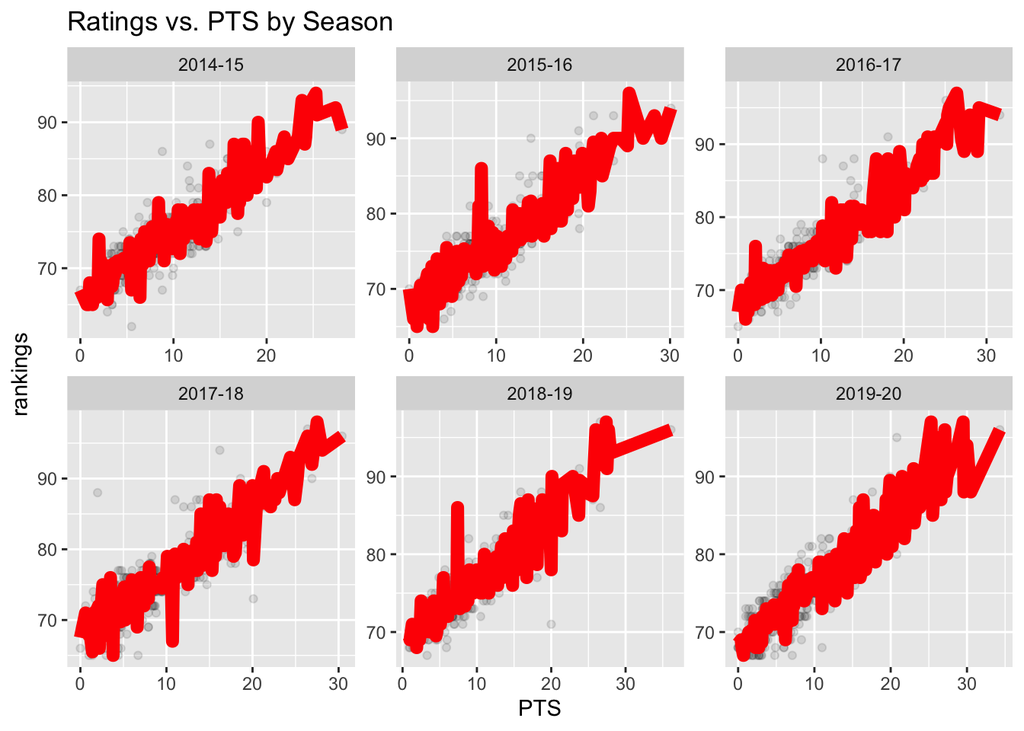

```r
ratings %>%
  ggplot(aes(PTS, rankings)) +
  geom_point(alpha = 0.1) +
  stat_summary(fun = mean, colour="red", geom="line", size = 3)+
  facet_wrap(~SEASON, scales = "free") +
  labs(
    title = "Ratings vs. PTS by Season"
  )
```

#### Ratings vs. Rebounds by Season

However, is rebounds positively correlated to a players’s ratings. Applying the same mechanism above,

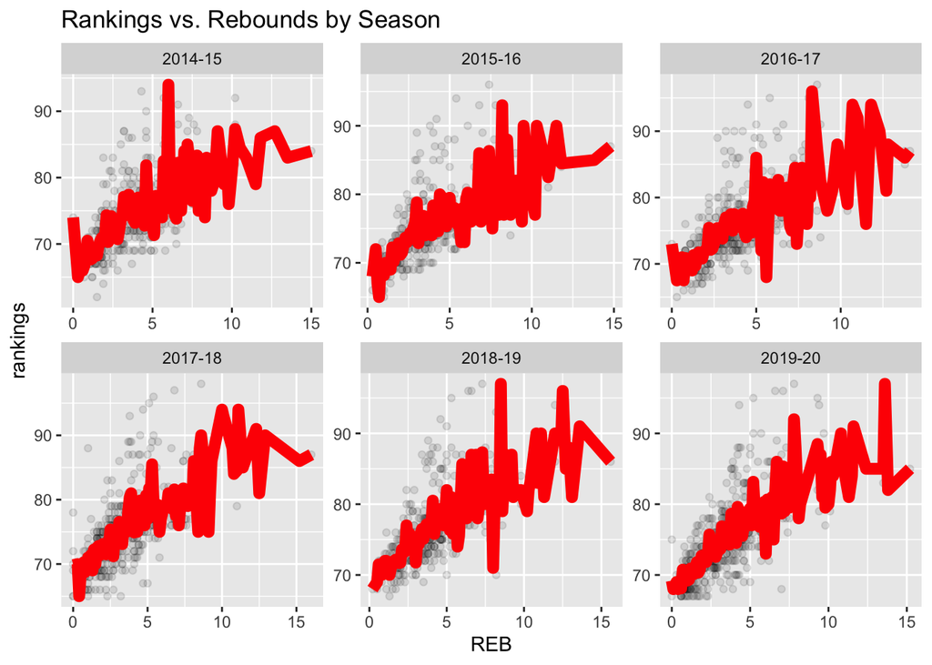

```r
ratings %>%
  ggplot(aes(REB, rankings)) +
  geom_point(alpha = 0.1) +
  stat_summary(fun = mean, colour="red", geom="line", size = 3)+
  facet_wrap(~SEASON, scales = "free") +
  labs(
    title = "Rankings vs. Rebounds by Season"
  )
```

we see that The linear relationship is not that strong, meaning that even though some player can grab a lot of rebounds, this does not make them a good player.

#### Ratings vs. Turnovers by Season

The last thing we want to investigate is turnovers. We know that turnovers are bad, but does more turnovers makes a player a bad player?

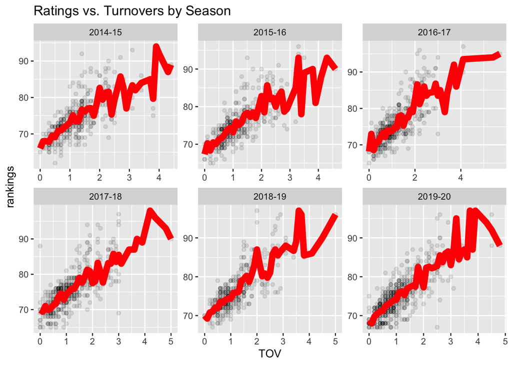

```r
ratings %>%
  ggplot(aes(TOV, rankings)) +
  geom_point(alpha = 0.1) +
  stat_summary(fun = mean, colour="red", geom="line", size = 3)+
  facet_wrap(~SEASON, scales = "free") +
  labs(
    title = "Ratings vs. Turnovers by Season"
  )
```

We see that, in fact, turnovers are quite positively corelated with ratings. In our case, Westbrook is known for his turnovers, so maybe he turn out to be a great player with our model prediction.

#### Correlation Matrix

We can also use a correlation plot to see how each variables are correlated

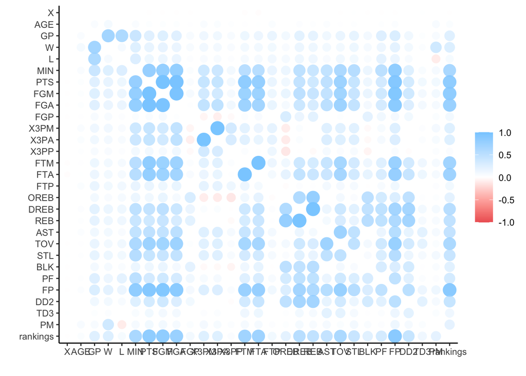

```r
library("dplyr")
cor_ratings <- select_if(ratings,is.numeric) %>% correlate()
rplot(cor_ratings)
```

## Modeling

### Random Forest

Since the model is downloaded on Kaggle and everything is cleaned up, there is no need to do extra data cleaning. Since we found some obvious linear relationships from our exploratory data analysis, we will first attempt to fit a Random Forest model.

```r
ratings <- read.csv(file = 'data/nba_rankings_2014-2020.csv') %>%
  mutate(TEAM = factor(TEAM))
```

#### Data Split

The data was split in a 80% training, 20% testing split.

```r
ratings_split <- ratings %>% initial_split(prop = 0.8)

ratings_train <- training(ratings_split)
ratings_test <- testing(ratings_split)
```

We also fold the data in 5 folds, this will be used for our tuning and cross validation process.

```r
ratings_folds <- vfold_cv(ratings_train, v = 5)
```

Now we create a random forest specification, we tune `mtry`, `trees`, and `min_n`. We let `levels = 5` so that the training would not take too much of time. We next specify a grid for tuning, as we can see from the code below, `mtry` is ranged from 1 to 20, `trees` is ranged from 100 to 2000, and `min_n` is ranged from 1 to 20. We next create a workflow adding our specification and formula into it.

```r
rand_tree_spec <- rand_forest(
  mode = "regression",
  mtry = tune(),
  trees = tune(),
  min_n = tune()
) %>%
set_engine("ranger")

rand_tree_grid <- grid_regular(mtry(c(1,20)),trees(c(100,2000)),min_n(c(1,20)),levels = 5)

rand_tree_wf <- workflow() %>%
  add_model(rand_tree_spec) %>%
  add_formula(rankings ~ TEAM + AGE + GP + W + L + MIN + PTS + FGM + FGM + FGA
   + FGP + X3PM + X3PA + X3PP + FTM + FTA + FTP + OREB + DREB + REB + AST
   + TOV + STL + BLK + PF + FP + DD2 + TD3 + PM)
```

and we tune the model, plotting the tuning results.

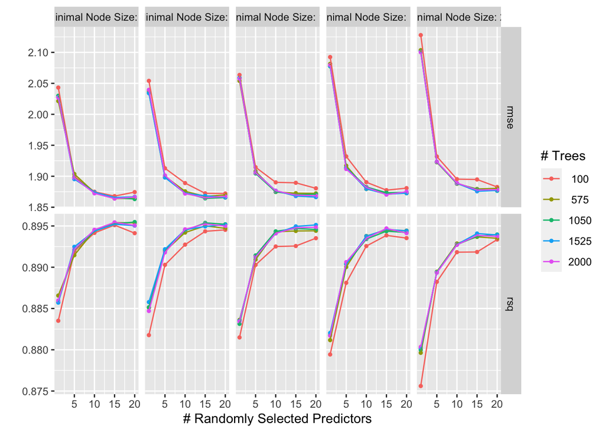

```r
library(ranger)
rand_tune_res <- tune_grid(
  rand_tree_wf,
  resamples = ratings_folds,
  grid = rand_tree_grid,
)

autoplot(rand_tune_res)
```

From the above tuning results, we see that in general higher number of `trees` and `mtry` yields better results. We then find the best model with the following code.

```r
best_rand_forest <- select_best(rand_tune_res)

rand_tree_final <- finalize_workflow(rand_tree_wf, best_rand_forest)

rand_tree_final_fit <- fit(rand_tree_final, data = ratings_train)

rand_tree_final_fit %>% extract_fit_engine()
```

```
## Ranger result
##
## Call:
##  ranger::ranger(x = maybe_data_frame(x), y = y, mtry = min_cols(~20L,      x), num.trees = ~1050L, min.node.size = min_rows(~1L, x),      num.threads = 1, verbose = FALSE, seed = sample.int(10^5,          1))
##
## Type:                             Regression
## Number of trees:                  1050
## Sample size:                      1929
## Number of independent variables:  28
## Mtry:                             20
## Target node size:                 1
## Variable importance mode:         none
## Splitrule:                        variance
## OOB prediction error (MSE):       3.537665
## R squared (OOB):                  0.8934689
```

We will do our fitting on the testing data at the next section. But on the training data,

```r
final_rand_model = augment(rand_tree_final_fit, new_data = ratings_train)
bind_rows(
  rmse(final_rand_model, truth = rankings, estimate = .pred),
  rsq(final_rand_model, truth = rankings, estimate = .pred))
```

```
## # A tibble: 2 × 3
##   .metric .estimator .estimate
##   <chr>   <chr>          <dbl>
## 1 rmse    standard       0.691
## 2 rsq     standard       0.986
```

The RMSE is pretty low and the R-squared is pretty high. which means that our model is pretty good on the training set. We will investigate its performance on the testing data next section

### Boosted trees

In this subsection, we will attempt to fit a boosted tree model on the dataset, similar to the previous one, we will first create a specification, and then tune the model.

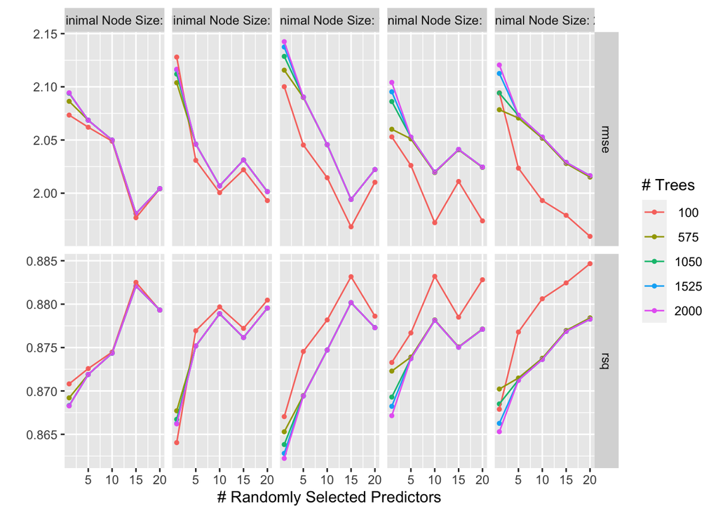

```r
boost_tree_spec <- boost_tree(mtry = tune(), trees = tune(),min_n = tune()) %>%
  set_engine("xgboost") %>%
  set_mode("regression")

boost_tree_grid <- grid_regular(mtry(c(1,20)),trees(c(100,2000)),min_n(c(1,20)),levels = 5)

boost_tree_wf <- workflow() %>%
  add_model(boost_tree_spec) %>%
  add_formula(rankings ~ TEAM + AGE + GP + W + L + MIN + PTS + FGM + FGM + FGA
   + FGP + X3PM + X3PA + X3PP + FTM + FTA + FTP + OREB + DREB + REB + AST
   + TOV + STL + BLK + PF + FP + DD2 + TD3 + PM)

boost_tune_res <- tune_grid(
  boost_tree_wf,
  resamples = ratings_folds,
  grid = boost_tree_grid,
)

autoplot(boost_tune_res)
```

Looking at the tunining plot of the boosted tree, interestingly, the `rmsq` and `rsq` do not converge as `trees` and `mtry` or `min_n` increases. And again, We then find the best model with the following code.

```r
best_boost_tree <- select_best(boost_tune_res)

boost_tree_final <- finalize_workflow(boost_tree_wf, best_boost_tree)

boost_tree_final_fit <- fit(boost_tree_final, data = ratings_train)
```

For the boosted tree model,

```r
final_boost_model = augment(boost_tree_final_fit, new_data = ratings_train)
bind_rows(
  rmse(final_boost_model, truth = rankings, estimate = .pred),
  rsq(final_boost_model, truth = rankings, estimate = .pred))
```

```
## # A tibble: 2 × 3
##   .metric .estimator .estimate
##   <chr>   <chr>          <dbl>
## 1 rmse    standard       0.759
## 2 rsq     standard       0.983
```

For the boosted tree model, the `rmse` is strikingly low and `rsq` is strikingly high. This may be due to some overfitting, and we will investigate this in the next section

### K Nearest Neighbors

In this subsection, we will attempt to fit a k-nearest neighbors on the dataset, similar to the previous one, we will first create a specification, and then tune the model.

```r
library(kknn)
recipe <-
  recipe(formula = rankings ~ TEAM + AGE + GP + W + L + MIN + PTS + FGM + FGM + FGA
   + FGP + X3PM + X3PA + X3PP + FTM + FTA + FTP + OREB + DREB + REB + AST
   + TOV + STL + BLK + PF + FP + DD2 + TD3 + PM, data = ratings_train) %>%
  step_novel(all_nominal_predictors()) %>%
  step_dummy(all_nominal_predictors()) %>%
  step_zv(all_predictors()) %>%
  step_normalize(all_predictors())
knn_model <-
  nearest_neighbor(
    neighbors = tune(),
    mode = "regression") %>%
  set_engine("kknn")

knn_workflow <- workflow() %>%
  add_model(knn_model) %>%
  add_recipe(recipe)
```

Unlike the previous tree models, we are only turning number of neighbors

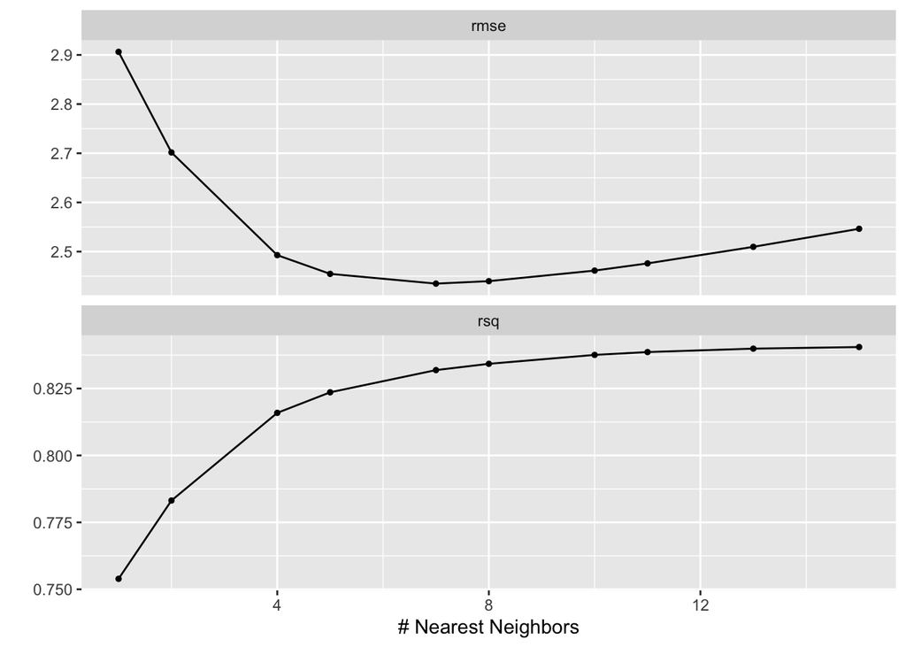

```r
knn_params <- parameters(knn_model)

knn_grid <- grid_regular(knn_params, levels = 10)

knn_tune <- knn_workflow %>%
  tune_grid(
    # what will it fit the workflow to
    resamples = ratings_folds,
    # how does it complete the models in those workflows
            grid = knn_grid)
autoplot(knn_tune)
```

```r
best_knn <- select_best(knn_tune)

knn_final <- finalize_workflow(knn_workflow, best_knn)

knn_final_fit <- fit(knn_final, data = ratings_train)
```

For our k-nearest neighbor model,

```r
final_knn_model = augment(knn_final_fit, new_data = ratings_train)
bind_rows(
  rmse(final_knn_model, truth = rankings, estimate = .pred),
  rsq(final_knn_model, truth = rankings, estimate = .pred))
```

```
## # A tibble: 2 × 3
##   .metric .estimator .estimate
##   <chr>   <chr>          <dbl>
## 1 rmse    standard       1.36
## 2 rsq     standard       0.951
```

The `rmse` is pretty low and the `rsq` is pretty high. which means that our model is pretty good on the training set. We will investigate its performance on the testing data next section

### Lasso regression

In this subsection, we will attempt to fit a lasso regression on the dataset, similar to the previous one, we will first create a specification, and then tune the model. As we can see from the recipe, we are normalizing to predictors and made the nominal predictors dummy. We are using the `glmnet` engine to perform the regression.

```r
lasso_recipe <-
  recipe(formula = rankings ~ TEAM + AGE + GP + W + L + MIN + PTS + FGM + FGM + FGA
   + FGP + X3PM + X3PA + X3PP + FTM + FTA + FTP + OREB + DREB + REB + AST
   + TOV + STL + BLK + PF + FP + DD2 + TD3 + PM, data = ratings_train) %>%
  step_novel(all_nominal_predictors()) %>%
  step_dummy(all_nominal_predictors()) %>%
  step_zv(all_predictors()) %>%
  step_normalize(all_predictors())

lasso_spec <-
  linear_reg(penalty = tune(), mixture = 1) %>%
  set_mode("regression") %>%
  set_engine("glmnet")

lasso_workflow <- workflow() %>%
  add_recipe(lasso_recipe) %>%
  add_model(lasso_spec)
```

While we are doing a different kind of regularization, we still use the same penalty argument. We’ve picked a different range for the values of penalty, since we know it will be a good range. You would, in practice, have to search a wide range of values at first, then narrow in on a range of interest.

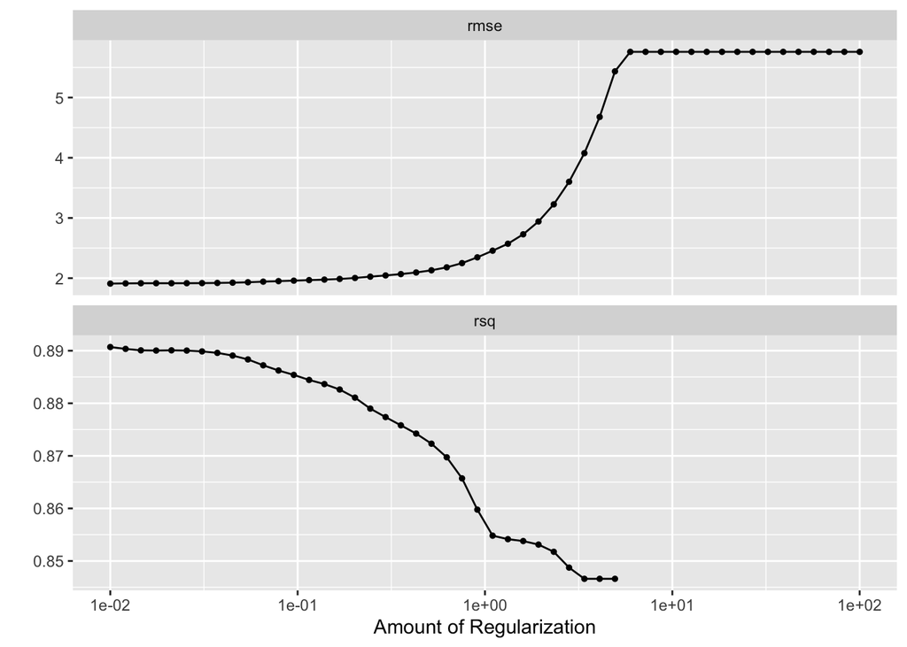

```r
penalty_grid <- grid_regular(penalty(range = c(-2, 2)), levels = 50)
tune_res <- tune_grid(
  lasso_workflow,
  resamples = ratings_folds,
  grid = penalty_grid
)

autoplot(tune_res)
```

We can see from the above tuning diagram. `rmse` increases as the amount of regularizaiton increases. And `rsq` decreases as the amount of regularization increases. Similar to what we have done to other models, we will choose a best model.

```r
best_penalty <- select_best(tune_res, metric = "rsq")
lasso_final <- finalize_workflow(lasso_workflow, best_penalty)

lasso_final_fit <- fit(lasso_final, data = ratings_train)
```

Now, for our lasso model,

```r
final_lasso_model = augment(lasso_final_fit, new_data = ratings_train)
bind_rows(
  rmse(final_lasso_model, truth = rankings, estimate = .pred),
  rsq(final_lasso_model, truth = rankings, estimate = .pred))
```

```
## # A tibble: 2 × 3
##   .metric .estimator .estimate
##   <chr>   <chr>          <dbl>
## 1 rmse    standard       1.86
## 2 rsq     standard       0.896
```

So the model also did well.

### Fit Results

#### RMSE

Now we look at the performance of these four models. We first look at the `rmse` of each models

```r
final_rand_model = augment(rand_tree_final_fit, new_data = ratings_test)
final_knn_model = augment(knn_final_fit, new_data = ratings_test)
final_lasso_model = augment(lasso_final_fit, new_data = ratings_test)
final_boost_model = augment(boost_tree_final_fit, new_data = ratings_test)

results_rmse <- bind_rows(
  rmse(final_rand_model, truth = rankings, estimate = .pred),
  rmse(final_knn_model, truth = rankings, estimate = .pred),
  rmse(final_lasso_model, truth = rankings, estimate = .pred),
  rmse(final_boost_model, truth = rankings, estimate = .pred)
)
results_rmse
```

```
## # A tibble: 4 × 3
##   .metric .estimator .estimate
##   <chr>   <chr>          <dbl>
## 1 rmse    standard        2.05
## 2 rmse    standard        2.62
## 3 rmse    standard        2.13
## 4 rmse    standard        2.18
```

A low RMSE value indicates that the simulated and observed data are close to each other showing a better accuracy. Thus lower the RMSE better is model performance. The RMSE is a good measure for evaluating the performance of a model because RMSE is proportional to the observed mean. Interestingly, the random forest have the lowest rmse on the testing set. For our boosted tree model, even though it performed super good on the training set, on the testing set it was not as good as the ramdom forest, this means that there is some degree of **overfitting** in our boosted tree model.

#### RSQ

Another metric to look at is `rsq`, for our models,

```r
results_rsq <- bind_rows(
  rsq(final_rand_model, truth = rankings, estimate = .pred),
  rsq(final_knn_model, truth = rankings, estimate = .pred),
  rsq(final_lasso_model, truth = rankings, estimate = .pred),
  rsq(final_boost_model, truth = rankings, estimate = .pred)
)
results_rsq
```

```
## # A tibble: 4 × 3
##   .metric .estimator .estimate
##   <chr>   <chr>          <dbl>
## 1 rsq     standard       0.881
## 2 rsq     standard       0.816
## 3 rsq     standard       0.872
## 4 rsq     standard       0.865
```

## Conclusion

Remember that our goal was to answer this ultimate question,

**So the key question arises: Is Westbrook a good player in the 2021-22 season?**

Now, we will find out!

We have Some statistics of Westbrook’s 2021-22 season. We will use these statistics to answer this question. We enter Westbrook’s statistics as a tibble, and then predict with our model

```r
westbrook <- tibble(TEAM = 'LAL', AGE = 33, GP = 78,SEASON = '2021-22', W = 33, L = 49, MIN = 34.3,PTS = 18.5,
FGM = 7.0, FGA = 15.8, FGP = 44.4, X3PM = 1.0, X3PA = 3.4, X3PP = 29.8, FTM = 3.4, FTA = 5.1, FTP = 66,
OREB = 1.4, DREB = 6.0, REB = 7.4, AST = 7.1, TOV = 3.8, STL = 1.0,BLK = 0.3, PF = 3.0, FP = 37.8, DD2= 28,TD3 = 10, PM = -2.7)

predict(rand_tree_final_fit, new_data = westbrook)
```

```
## # A tibble: 1 × 1
##   .pred
##   <dbl>
## 1  84.1
```

So the predicted value of Russel Westbrook is 84. So According to our analysis, Westbrook is still a good player based solely on his statistics of this season.

Okay, but what is Westbrook, actual rating? We look at the 2k ratings database, Westbrook’s rating was 86 at the time the game was lauched and dropped to 78 as of today. Since our data was only from 2014-2020, we can see that our model’s prediction is reasonable.